# Principal Component Analysis with Cancer Data

# Q8 Find variance and cumulative variance by each eigen vector

```python
eigen_pairs = [(np.abs(eig_vals[i]), eig_vecs[ i, :]) for i in range(len(eig_vals))]
```

```python
tot = sum(eig_vals)
var_exp = [( i /tot ) * 100 for i in sorted(eig_vals, reverse=True)]
var_exp
```

```
[59.93054679415306,
 8.773123345738838,
 7.260543958134698,
 6.6229748760774125,
 4.5137081128431165,
 4.19514851514224,
 3.6910802456313196,
 3.6016704389155967,
 1.4112037133637159]
```

```python
cum_var_exp = np.cumsum(var_exp)
print("Cumulative Variance Explained", cum_var_exp)
```

```
Cumulative Variance Explained [ 59.93054679  68.70367014  75.9642141   82.58718897  87.10089709
  91.2960456   94.98712585  98.58879629 100.        ]
```

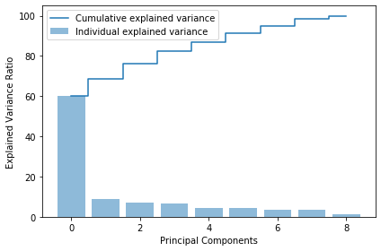

```python
plt.figure(figsize=(6 , 4))
plt.bar(range(9), var_exp, alpha = 0.5, align = 'center', label = 'Individual explained variance')
plt.step(range(9), cum_var_exp, where='mid', label = 'Cumulative explained variance')
plt.ylabel('Explained Variance Ratio')
plt.xlabel('Principal Components')
plt.legend(loc = 'best')
plt.tight_layout()
plt.show()
```

# Q9 Use PCA command from sklearn and find Principal Components. Transform data to components formed

```python
from sklearn.decomposition import PCA
pca = PCA(n_components=8)
principalComponents = pca.fit_transform(X_train_std)
principalDf = pd.DataFrame(data = principalComponents)
```

```python
principalDf.head()
```

|  | 0 | 1 | 2 | 3 | 4 | 5 | 6 | 7 |
| --- | --- | --- | --- | --- | --- | --- | --- | --- |
| 0 | 0.124651 | -0.083709 | 1.099733 | 1.232517 | 0.223863 | -0.694530 | -0.015857 | 0.318776 |
| 1 | 2.212232 | -1.177929 | 0.167570 | 0.218447 | -0.524616 | -0.930966 | -0.425442 | -0.769312 |
| 2 | 3.194585 | -1.562489 | 0.188969 | 0.186288 | 0.174531 | 2.041564 | 0.798099 | 0.449084 |
| 3 | -2.240985 | 0.053861 | -0.460509 | 0.266724 | 0.083149 | 0.213783 | 0.252564 | -0.025574 |
| 4 | -2.236650 | 0.213902 | 1.053214 | 0.502324 | 0.205455 | -0.253845 | -0.044264 | 0.942779 |

```python
principalComponents
```

```
array([[ 0.12465134, -0.08370857,  1.09973252, ..., -0.69453034,
        -0.01585737,  0.31877642],
       [ 2.2122323 , -1.17792896,  0.1675697 , ..., -0.93096646,
        -0.42544206, -0.76931225],
       [ 3.19458521, -1.56248945,  0.18896875, ...,  2.04156382,
         0.79809923,  0.44908445],
       ...,
       [-0.53858466, -0.4819428 , -0.09953428, ..., -0.89048304,
         0.25979068, -0.74207937],
       [-2.04385598, -0.12349372, -0.30920357, ...,  0.24088122,
         0.42355016,  0.20762101],
       [-2.54219723, -0.03310759,  0.80115582, ...,  0.1911239 ,
        -0.24298257,  0.17602733]])
```

# Q10 Find correlation between components and features

```python
#Correlation between components
```

```python
principalDf.corr()
```

|  | 0 | 1 | 2 | 3 | 4 | 5 | 6 | 7 |
| --- | --- | --- | --- | --- | --- | --- | --- | --- |
| 0 | 1.000000e+00 | 8.806524e-17 | -9.053066e-17 | -1.117725e-16 | -4.745541e-17 | 8.140004e-17 | 4.093269e-16 | 4.509162e-17 |
| 1 | 8.806524e-17 | 1.000000e+00 | 1.473926e-16 | 5.918412e-17 | 1.581877e-16 | 1.405298e-16 | -5.329527e-17 | 1.656999e-16 |
| 2 | -9.053066e-17 | 1.473926e-16 | 1.000000e+00 | -1.504224e-16 | -1.596183e-16 | -3.052655e-16 | 5.313727e-17 | 6.719444e-17 |
| 3 | -1.117725e-16 | 5.918412e-17 | -1.504224e-16 | 1.000000e+00 | -8.245254e-17 | -2.425037e-16 | -5.708002e-17 | 9.178596e-17 |
| 4 | -4.745541e-17 | 1.581877e-16 | -1.596183e-16 | -8.245254e-17 | 1.000000e+00 | -2.281974e-16 | 4.512323e-17 | 1.965887e-16 |
| 5 | 8.140004e-17 | 1.405298e-16 | -3.052655e-16 | -2.425037e-16 | -2.281974e-16 | 1.000000e+00 | 1.621247e-16 | -9.623424e-17 |
| 6 | 4.093269e-16 | -5.329527e-17 | 5.313727e-17 | -5.708002e-17 | 4.512323e-17 | 1.621247e-16 | 1.000000e+00 | 7.492313e-17 |
| 7 | 4.509162e-17 | 1.656999e-16 | 6.719444e-17 | 9.178596e-17 | 1.965887e-16 | -9.623424e-17 | 7.492313e-17 | 1.000000e+00 |

```python
# correlation between feature
```

```python
cancer_df.corr()
```

|  | ClumpThickness | Cell Size | Cell Shape | Marginal Adhesion | Single Epithelial Cell Size | Bare Nuclei | Normal Nucleoli | Bland Chromatin | Mitoses | Class |
| --- | --- | --- | --- | --- | --- | --- | --- | --- | --- | --- |
| ClumpThickness | 1.000000 | 0.578156 | 0.588956 | 0.383573 | 0.432165 | 0.507318 | 0.496158 | 0.450853 | 0.361751 | 0.675748 |
| Cell Size | 0.578156 | 1.000000 | 0.877404 | 0.640096 | 0.689982 | 0.588370 | 0.712986 | 0.657170 | 0.433995 | 0.757623 |
| Cell Shape | 0.588956 | 0.877404 | 1.000000 | 0.612415 | 0.649388 | 0.615732 | 0.687331 | 0.654724 | 0.398773 | 0.757932 |
| Marginal Adhesion | 0.383573 | 0.640096 | 0.612415 | 1.000000 | 0.528163 | 0.588980 | 0.611294 | 0.514134 | 0.400507 | 0.622371 |
| Single Epithelial Cell Size | 0.432165 | 0.689982 | 0.649388 | 0.528163 | 1.000000 | 0.480300 | 0.554625 | 0.558757 | 0.427359 | 0.604709 |
| Bare Nuclei | 0.507318 | 0.588370 | 0.615732 | 0.588980 | 0.480300 | 1.000000 | 0.604511 | 0.473021 | 0.360908 | 0.756155 |
| Normal Nucleoli | 0.496158 | 0.712986 | 0.687331 | 0.611294 | 0.554625 | 0.604511 | 1.000000 | 0.607259 | 0.315329 | 0.707166 |
| Bland Chromatin | 0.450853 | 0.657170 | 0.654724 | 0.514134 | 0.558757 | 0.473021 | 0.607259 | 1.000000 | 0.414004 | 0.639909 |
| Mitoses | 0.361751 | 0.433995 | 0.398773 | 0.400507 | 0.427359 | 0.360908 | 0.315329 | 0.414004 | 1.000000 | 0.446575 |
| Class | 0.675748 | 0.757623 | 0.757932 | 0.622371 | 0.604709 | 0.756155 | 0.707166 | 0.639909 | 0.446575 | 1.000000 |

# Popularity Based Recommendation System

### About Dataset

Anonymous Ratings on jokes.

1. Ratings are real values ranging from -10.00 to +10.00 (the value "99" corresponds to "null" = "not rated").
2. One row per user
3. The first column gives the number of jokes rated by that user. The next 100 columns give the ratings for jokes 01 - 100.

# Q11 Read the dataset(jokes.csv)

```python
jokes_df = pd.read_csv('jokes.csv')
```

```python
jokes_df.head()
```

|  | NumJokes | Joke1 | Joke2 | Joke3 | Joke4 | Joke5 | Joke6 | Joke7 | Joke8 | Joke9 | ... | Joke91 | Joke92 | Joke93 | Joke94 | Joke95 | Joke96 | Joke97 | Joke98 | Joke99 | Joke100 |
| --- | --- | --- | --- | --- | --- | --- | --- | --- | --- | --- | --- | --- | --- | --- | --- | --- | --- | --- | --- | --- | --- |
| 0 | 74 | -7.82 | 8.79 | -9.66 | -8.16 | -7.52 | -8.50 | -9.85 | 4.17 | -8.98 | ... | 2.82 | 99.00 | 99.00 | 99.00 | 99.00 | 99.00 | -5.63 | 99.00 | 99.00 | 99.00 |
| 1 | 100 | 4.08 | -0.29 | 6.36 | 4.37 | -2.38 | -9.66 | -0.73 | -5.34 | 8.88 | ... | 2.82 | -4.95 | -0.29 | 7.86 | -0.19 | -2.14 | 3.06 | 0.34 | -4.32 | 1.07 |
| 2 | 49 | 99.00 | 99.00 | 99.00 | 99.00 | 9.03 | 9.27 | 9.03 | 9.27 | 99.00 | ... | 99.00 | 99.00 | 99.00 | 9.08 | 99.00 | 99.00 | 99.00 | 99.00 | 99.00 | 99.00 |
| 3 | 48 | 99.00 | 8.35 | 99.00 | 99.00 | 1.80 | 8.16 | -2.82 | 6.21 | 99.00 | ... | 99.00 | 99.00 | 99.00 | 0.53 | 99.00 | 99.00 | 99.00 | 99.00 | 99.00 | 99.00 |
| 4 | 91 | 8.50 | 4.61 | -4.17 | -5.39 | 1.36 | 1.60 | 7.04 | 4.61 | -0.44 | ... | 5.19 | 5.58 | 4.27 | 5.19 | 5.73 | 1.55 | 3.11 | 6.55 | 1.80 | 1.60 |

5 rows × 101 columns

# Q12 Consider `ratings` named dataframe with only first 200 rows and all columns from 1(first column is 0) of dataset

```python
ratings = jokes_df.iloc[:200,1:]
```

```python
ratings.head()
```

|  | Joke1 | Joke2 | Joke3 | Joke4 | Joke5 | Joke6 | Joke7 | Joke8 | Joke9 | Joke10 | ... | Joke91 | Joke92 | Joke93 | Joke94 | Joke95 | Joke96 | Joke97 | Joke98 | Joke99 | Joke100 |
| --- | --- | --- | --- | --- | --- | --- | --- | --- | --- | --- | --- | --- | --- | --- | --- | --- | --- | --- | --- | --- | --- |
| 0 | -7.82 | 8.79 | -9.66 | -8.16 | -7.52 | -8.50 | -9.85 | 4.17 | -8.98 | -4.76 | ... | 2.82 | 99.00 | 99.00 | 99.00 | 99.00 | 99.00 | -5.63 | 99.00 | 99.00 | 99.00 |
| 1 | 4.08 | -0.29 | 6.36 | 4.37 | -2.38 | -9.66 | -0.73 | -5.34 | 8.88 | 9.22 | ... | 2.82 | -4.95 | -0.29 | 7.86 | -0.19 | -2.14 | 3.06 | 0.34 | -4.32 | 1.07 |
| 2 | 99.00 | 99.00 | 99.00 | 99.00 | 9.03 | 9.27 | 9.03 | 9.27 | 99.00 | 99.00 | ... | 99.00 | 99.00 | 99.00 | 9.08 | 99.00 | 99.00 | 99.00 | 99.00 | 99.00 | 99.00 |
| 3 | 99.00 | 8.35 | 99.00 | 99.00 | 1.80 | 8.16 | -2.82 | 6.21 | 99.00 | 1.84 | ... | 99.00 | 99.00 | 99.00 | 0.53 | 99.00 | 99.00 | 99.00 | 99.00 | 99.00 | 99.00 |
| 4 | 8.50 | 4.61 | -4.17 | -5.39 | 1.36 | 1.60 | 7.04 | 4.61 | -0.44 | 5.73 | ... | 5.19 | 5.58 | 4.27 | 5.19 | 5.73 | 1.55 | 3.11 | 6.55 | 1.80 | 1.60 |

5 rows × 100 columns

# Q13 In the dataset, the null ratings are given as 99.00, so replace all 99.00s with 0

Hint: You can use `ratings.replace(<the given value>, <new value you wanted to change with>)`

```python
ratings.replace(99,0, inplace=True)
```

```python
ratings.head()
```

|  | Joke1 | Joke2 | Joke3 | Joke4 | Joke5 | Joke6 | Joke7 | Joke8 | Joke9 | Joke10 | ... | Joke91 | Joke92 | Joke93 | Joke94 | Joke95 | Joke96 | Joke97 | Joke98 | Joke99 | Joke100 |
| --- | --- | --- | --- | --- | --- | --- | --- | --- | --- | --- | --- | --- | --- | --- | --- | --- | --- | --- | --- | --- | --- |
| 0 | -7.82 | 8.79 | -9.66 | -8.16 | -7.52 | -8.50 | -9.85 | 4.17 | -8.98 | -4.76 | ... | 2.82 | 0.00 | 0.00 | 0.00 | 0.00 | 0.00 | -5.63 | 0.00 | 0.00 | 0.00 |
| 1 | 4.08 | -0.29 | 6.36 | 4.37 | -2.38 | -9.66 | -0.73 | -5.34 | 8.88 | 9.22 | ... | 2.82 | -4.95 | -0.29 | 7.86 | -0.19 | -2.14 | 3.06 | 0.34 | -4.32 | 1.07 |
| 2 | 0.00 | 0.00 | 0.00 | 0.00 | 9.03 | 9.27 | 9.03 | 9.27 | 0.00 | 0.00 | ... | 0.00 | 0.00 | 0.00 | 9.08 | 0.00 | 0.00 | 0.00 | 0.00 | 0.00 | 0.00 |
| 3 | 0.00 | 8.35 | 0.00 | 0.00 | 1.80 | 8.16 | -2.82 | 6.21 | 0.00 | 1.84 | ... | 0.00 | 0.00 | 0.00 | 0.53 | 0.00 | 0.00 | 0.00 | 0.00 | 0.00 | 0.00 |
| 4 | 8.50 | 4.61 | -4.17 | -5.39 | 1.36 | 1.60 | 7.04 | 4.61 | -0.44 | 5.73 | ... | 5.19 | 5.58 | 4.27 | 5.19 | 5.73 | 1.55 | 3.11 | 6.55 | 1.80 | 1.60 |

5 rows × 100 columns

### Popularity based recommendation system

# Q14 Find the mean for each column in `ratings_diff` i.e, for each joke

Consider all the mean ratings and find the jokes with highest mean value and display the top 10 joke IDs.

```python
#print("Top 10 Jokes (ID, mean score)")
#print(ratings.mean().sort_values(ascending=False).head(10))
jokeMeandf = pd.DataFrame(data = ratings.mean())
print('Top 10 Jokes IDs with Highest Mean:\n')
jokeMeandf.sort_values(by=0,ascending=False).head(10)
```

```
Top 10 Jokes IDs with Highest Mean:
```

|  | 0 |
| --- | --- |
| Joke50 | 4.05540 |
| Joke36 | 3.61150 |
| Joke53 | 3.57150 |
| Joke35 | 3.22315 |
| Joke29 | 3.18995 |
| Joke27 | 3.05240 |
| Joke62 | 2.86185 |
| Joke49 | 2.85000 |
| Joke32 | 2.77955 |
| Joke31 | 2.65710 |